# Risk Factor Analysis

## Outcome Variable

**Outcome Variable:** stunted

## Predictor Variables

**Intervention Variable:** perdiar24

**Adjustment Set:**

- arm
- sex
- meducyrs
- hhwealth_quart
- hfoodsec
- vagbrth
- hdlvry
- W_birthwt
- W_birthlen
- W_nrooms
- month
- brthmon
- impfloor
- impsan
- safeh20
- delta_meducyrs
- delta_hhwealth_quart
- delta_hfoodsec
- delta_vagbrth
- delta_hdlvry
- delta_W_birthwt
- delta_W_birthlen
- delta_W_nrooms
- delta_month
- delta_brthmon
- delta_impfloor
- delta_impsan
- delta_safeh20

## Stratifying Variables

The analysis was stratified on these variable(s):

- agecat
- studyid
- country

## Data Summary

| agecat | studyid | country | perdiar24 | stunted | n_cell | n |
| --- | --- | --- | --- | --- | --- | --- |
| Birth | ki0047075b-MAL-ED | BANGLADESH | (0%, 5%] | 0 | 126 | 257 |
| Birth | ki0047075b-MAL-ED | BANGLADESH | (0%, 5%] | 1 | 20 | 257 |
| Birth | ki0047075b-MAL-ED | BANGLADESH | >5% | 0 | 68 | 257 |
| Birth | ki0047075b-MAL-ED | BANGLADESH | >5% | 1 | 21 | 257 |
| Birth | ki0047075b-MAL-ED | BANGLADESH | 0% | 0 | 16 | 257 |
| Birth | ki0047075b-MAL-ED | BANGLADESH | 0% | 1 | 6 | 257 |
| Birth | ki0047075b-MAL-ED | BRAZIL | (0%, 5%] | 0 | 71 | 191 |
| Birth | ki0047075b-MAL-ED | BRAZIL | (0%, 5%] | 1 | 10 | 191 |
| Birth | ki0047075b-MAL-ED | BRAZIL | >5% | 0 | 2 | 191 |
| Birth | ki0047075b-MAL-ED | BRAZIL | >5% | 1 | 0 | 191 |
| Birth | ki0047075b-MAL-ED | BRAZIL | 0% | 0 | 97 | 191 |
| Birth | ki0047075b-MAL-ED | BRAZIL | 0% | 1 | 11 | 191 |
| Birth | ki0047075b-MAL-ED | INDIA | (0%, 5%] | 0 | 130 | 206 |
| Birth | ki0047075b-MAL-ED | INDIA | (0%, 5%] | 1 | 26 | 206 |
| Birth | ki0047075b-MAL-ED | INDIA | >5% | 0 | 33 | 206 |
| Birth | ki0047075b-MAL-ED | INDIA | >5% | 1 | 5 | 206 |
| Birth | ki0047075b-MAL-ED | INDIA | 0% | 0 | 10 | 206 |
| Birth | ki0047075b-MAL-ED | INDIA | 0% | 1 | 2 | 206 |
| Birth | ki0047075b-MAL-ED | NEPAL | (0%, 5%] | 0 | 96 | 173 |
| Birth | ki0047075b-MAL-ED | NEPAL | (0%, 5%] | 1 | 7 | 173 |
| Birth | ki0047075b-MAL-ED | NEPAL | >5% | 0 | 47 | 173 |
| Birth | ki0047075b-MAL-ED | NEPAL | >5% | 1 | 9 | 173 |
| Birth | ki0047075b-MAL-ED | NEPAL | 0% | 0 | 12 | 173 |
| Birth | ki0047075b-MAL-ED | NEPAL | 0% | 1 | 2 | 173 |
| Birth | ki0047075b-MAL-ED | PERU | (0%, 5%] | 0 | 95 | 287 |
| Birth | ki0047075b-MAL-ED | PERU | (0%, 5%] | 1 | 14 | 287 |
| Birth | ki0047075b-MAL-ED | PERU | >5% | 0 | 133 | 287 |
| Birth | ki0047075b-MAL-ED | PERU | >5% | 1 | 18 | 287 |
| Birth | ki0047075b-MAL-ED | PERU | 0% | 0 | 25 | 287 |
| Birth | ki0047075b-MAL-ED | PERU | 0% | 1 | 2 | 287 |

[output cut: 276 more lines]

The following strata were considered:

- agecat: 24 months, studyid: ki0047075b-MAL-ED, country: BANGLADESH
- agecat: 24 months, studyid: ki0047075b-MAL-ED, country: BRAZIL
- agecat: 24 months, studyid: ki0047075b-MAL-ED, country: INDIA
- agecat: 24 months, studyid: ki0047075b-MAL-ED, country: NEPAL
- agecat: 24 months, studyid: ki0047075b-MAL-ED, country: PERU
- agecat: 24 months, studyid: ki0047075b-MAL-ED, country: SOUTH AFRICA
- agecat: 24 months, studyid: ki0047075b-MAL-ED, country: TANZANIA, UNITED REPUBLIC OF
- agecat: 24 months, studyid: ki1017093-NIH-Birth, country: BANGLADESH
- agecat: 24 months, studyid: ki1017093b-PROVIDE, country: BANGLADESH
- agecat: 24 months, studyid: ki1017093c-NIH-Crypto, country: BANGLADESH
- agecat: 24 months, studyid: ki1114097-CMIN, country: BANGLADESH
- agecat: 24 months, studyid: ki1114097-CMIN, country: GUINEA-BISSAU
- agecat: 24 months, studyid: ki1114097-CMIN, country: PERU
- agecat: 24 months, studyid: ki1114097-CONTENT, country: PERU
- agecat: 24 months, studyid: kiGH5241-JiVitA-4, country: BANGLADESH
- agecat: 6 months, studyid: ki0047075b-MAL-ED, country: BANGLADESH
- agecat: 6 months, studyid: ki0047075b-MAL-ED, country: BRAZIL
- agecat: 6 months, studyid: ki0047075b-MAL-ED, country: INDIA
- agecat: 6 months, studyid: ki0047075b-MAL-ED, country: NEPAL
- agecat: 6 months, studyid: ki0047075b-MAL-ED, country: PERU
- agecat: 6 months, studyid: ki0047075b-MAL-ED, country: SOUTH AFRICA
- agecat: 6 months, studyid: ki0047075b-MAL-ED, country: TANZANIA, UNITED REPUBLIC OF
- agecat: 6 months, studyid: ki1000109-EE, country: PAKISTAN
- agecat: 6 months, studyid: ki1000109-ResPak, country: PAKISTAN
- agecat: 6 months, studyid: ki1000304b-SAS-FoodSuppl, country: INDIA
- agecat: 6 months, studyid: ki1017093-NIH-Birth, country: BANGLADESH
- agecat: 6 months, studyid: ki1017093b-PROVIDE, country: BANGLADESH
- agecat: 6 months, studyid: ki1017093c-NIH-Crypto, country: BANGLADESH
- agecat: 6 months, studyid: ki1112895-Guatemala BSC, country: GUATEMALA
- agecat: 6 months, studyid: ki1114097-CMIN, country: BANGLADESH
- agecat: 6 months, studyid: ki1114097-CMIN, country: BRAZIL
- agecat: 6 months, studyid: ki1114097-CMIN, country: GUINEA-BISSAU
- agecat: 6 months, studyid: ki1114097-CMIN, country: PERU
- agecat: 6 months, studyid: ki1114097-CONTENT, country: PERU
- agecat: 6 months, studyid: kiGH5241-JiVitA-4, country: BANGLADESH
- agecat: Birth, studyid: ki0047075b-MAL-ED, country: BANGLADESH
- agecat: Birth, studyid: ki0047075b-MAL-ED, country: BRAZIL
- agecat: Birth, studyid: ki0047075b-MAL-ED, country: INDIA
- agecat: Birth, studyid: ki0047075b-MAL-ED, country: NEPAL
- agecat: Birth, studyid: ki0047075b-MAL-ED, country: PERU
- agecat: Birth, studyid: ki0047075b-MAL-ED, country: SOUTH AFRICA
- agecat: Birth, studyid: ki0047075b-MAL-ED, country: TANZANIA, UNITED REPUBLIC OF
- agecat: Birth, studyid: ki1000109-EE, country: PAKISTAN
- agecat: Birth, studyid: ki1000109-ResPak, country: PAKISTAN
- agecat: Birth, studyid: ki1017093-NIH-Birth, country: BANGLADESH
- agecat: Birth, studyid: ki1017093c-NIH-Crypto, country: BANGLADESH
- agecat: Birth, studyid: ki1114097-CMIN, country: BANGLADESH
- agecat: Birth, studyid: ki1114097-CMIN, country: BRAZIL
- agecat: Birth, studyid: ki1114097-CMIN, country: PERU
- agecat: Birth, studyid: ki1114097-CONTENT, country: PERU
- agecat: Birth, studyid: kiGH5241-JiVitA-4, country: BANGLADESH

### Dropped Strata

Some strata were dropped due to rare outcomes:

- agecat: Birth, studyid: ki0047075b-MAL-ED, country: BRAZIL
- agecat: Birth, studyid: ki0047075b-MAL-ED, country: INDIA
- agecat: Birth, studyid: ki0047075b-MAL-ED, country: NEPAL
- agecat: Birth, studyid: ki0047075b-MAL-ED, country: PERU
- agecat: Birth, studyid: ki0047075b-MAL-ED, country: SOUTH AFRICA
- agecat: Birth, studyid: ki0047075b-MAL-ED, country: TANZANIA, UNITED REPUBLIC OF
- agecat: Birth, studyid: ki1000109-EE, country: PAKISTAN
- agecat: Birth, studyid: ki1000109-ResPak, country: PAKISTAN
- agecat: Birth, studyid: ki1017093-NIH-Birth, country: BANGLADESH
- agecat: Birth, studyid: ki1017093c-NIH-Crypto, country: BANGLADESH
- agecat: Birth, studyid: ki1114097-CMIN, country: BANGLADESH
- agecat: Birth, studyid: ki1114097-CMIN, country: BRAZIL
- agecat: Birth, studyid: ki1114097-CMIN, country: PERU
- agecat: Birth, studyid: ki1114097-CONTENT, country: PERU
- agecat: 6 months, studyid: ki0047075b-MAL-ED, country: BANGLADESH
- agecat: 6 months, studyid: ki0047075b-MAL-ED, country: BRAZIL
- agecat: 6 months, studyid: ki0047075b-MAL-ED, country: INDIA
- agecat: 6 months, studyid: ki0047075b-MAL-ED, country: NEPAL
- agecat: 6 months, studyid: ki0047075b-MAL-ED, country: PERU
- agecat: 6 months, studyid: ki0047075b-MAL-ED, country: SOUTH AFRICA
- agecat: 6 months, studyid: ki0047075b-MAL-ED, country: TANZANIA, UNITED REPUBLIC OF
- agecat: 6 months, studyid: ki1000109-ResPak, country: PAKISTAN
- agecat: 6 months, studyid: ki1017093b-PROVIDE, country: BANGLADESH
- agecat: 6 months, studyid: ki1114097-CMIN, country: BANGLADESH
- agecat: 6 months, studyid: ki1114097-CMIN, country: BRAZIL
- agecat: 6 months, studyid: ki1114097-CMIN, country: GUINEA-BISSAU
- agecat: 6 months, studyid: ki1114097-CMIN, country: PERU
- agecat: 6 months, studyid: ki1114097-CONTENT, country: PERU
- agecat: 24 months, studyid: ki0047075b-MAL-ED, country: BANGLADESH
- agecat: 24 months, studyid: ki0047075b-MAL-ED, country: BRAZIL
- agecat: 24 months, studyid: ki0047075b-MAL-ED, country: INDIA
- agecat: 24 months, studyid: ki0047075b-MAL-ED, country: NEPAL
- agecat: 24 months, studyid: ki0047075b-MAL-ED, country: PERU
- agecat: 24 months, studyid: ki0047075b-MAL-ED, country: SOUTH AFRICA
- agecat: 24 months, studyid: ki0047075b-MAL-ED, country: TANZANIA, UNITED REPUBLIC OF
- agecat: 24 months, studyid: ki1017093-NIH-Birth, country: BANGLADESH
- agecat: 24 months, studyid: ki1017093b-PROVIDE, country: BANGLADESH
- agecat: 24 months, studyid: ki1114097-CMIN, country: BANGLADESH
- agecat: 24 months, studyid: ki1114097-CONTENT, country: PERU

## Methods Detail

We’re interested in the causal parameters $E[Y_a]$ for all values of $a \in \mathcal{A}$. These parameters represent the mean outcome if, possibly contrary to fact, we intervened to set all units to have $A=a$. Under the randomization and positivity assumptions, these are identified by the statistical parameters $\psi_a=E_W[E_{Y|A,W}(Y|A=a,W)]$. In addition, we’re interested in the mean of $Y$, $E[Y]$ under no intervention (the observed mean). We will estimate these parameters by using SuperLearner to fit the relevant likelihood factors – $E_{Y|A,W}(Y|A=a,W)$ and $p(A=a|W)$, and then updating our likelihood fit using a joint TMLE.

For unadjusted analyses ($W=\{\}$), initial likelihoods were estimated using Lrnr_glm to estimate the simple $E(Y|A)$ and Lrnr_mean to estimate $p(A)$. For adjusted analyses, a small library containing Lrnr_glmnet, Lrnr_xgboost, and Lrnr_mean was used.

Having estimated these parameters, we will then use the delta method to estimate relative risks and attributable risks relative to a prespecified baseline level of $A$.

# Results Detail

## Results Plots

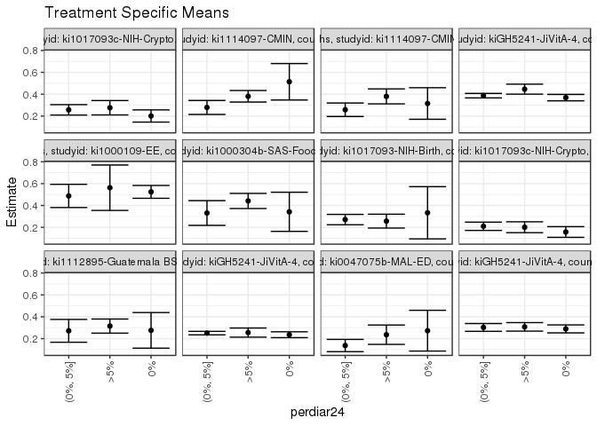

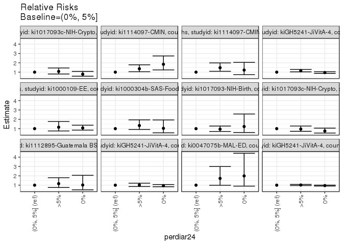

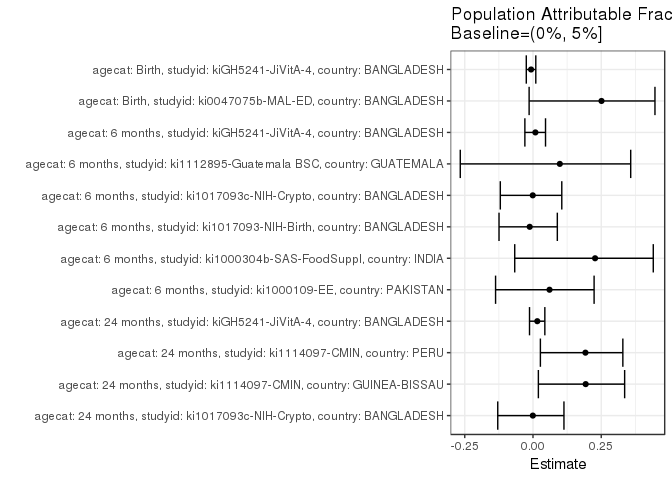

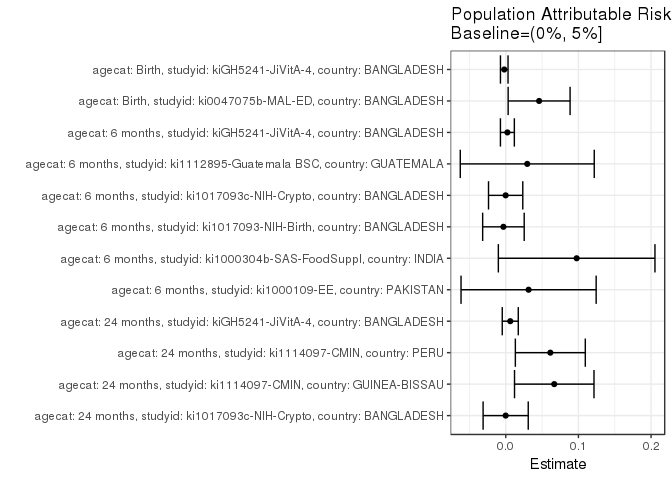

## Results Table

### Parameter: TSM

| agecat | studyid | country | intervention_level | baseline_level | estimate | ci_lower | ci_upper |
| --- | --- | --- | --- | --- | --- | --- | --- |
| Birth | ki0047075b-MAL-ED | BANGLADESH | (0%, 5%] | NA | 0.1369863 | 0.0811051 | 0.1928675 |
| Birth | ki0047075b-MAL-ED | BANGLADESH | >5% | NA | 0.2359551 | 0.1475710 | 0.3243391 |
| Birth | ki0047075b-MAL-ED | BANGLADESH | 0% | NA | 0.2727273 | 0.0862627 | 0.4591918 |
| Birth | kiGH5241-JiVitA-4 | BANGLADESH | (0%, 5%] | NA | 0.3025890 | 0.2668158 | 0.3383621 |
| Birth | kiGH5241-JiVitA-4 | BANGLADESH | >5% | NA | 0.3077849 | 0.2688696 | 0.3467001 |
| Birth | kiGH5241-JiVitA-4 | BANGLADESH | 0% | NA | 0.2892355 | 0.2528074 | 0.3256636 |
| 6 months | ki1000109-EE | PAKISTAN | (0%, 5%] | NA | 0.4874027 | 0.3813044 | 0.5935010 |
| 6 months | ki1000109-EE | PAKISTAN | >5% | NA | 0.5625298 | 0.3549093 | 0.7701502 |
| 6 months | ki1000109-EE | PAKISTAN | 0% | NA | 0.5244984 | 0.4658666 | 0.5831302 |
| 6 months | ki1000304b-SAS-FoodSuppl | INDIA | (0%, 5%] | NA | 0.3313838 | 0.2183309 | 0.4444368 |
| 6 months | ki1000304b-SAS-FoodSuppl | INDIA | >5% | NA | 0.4415284 | 0.3722370 | 0.5108197 |
| 6 months | ki1000304b-SAS-FoodSuppl | INDIA | 0% | NA | 0.3422295 | 0.1632300 | 0.5212291 |
| 6 months | ki1017093-NIH-Birth | BANGLADESH | (0%, 5%] | NA | 0.2713864 | 0.2240064 | 0.3187665 |
| 6 months | ki1017093-NIH-Birth | BANGLADESH | >5% | NA | 0.2568306 | 0.1934736 | 0.3201876 |
| 6 months | ki1017093-NIH-Birth | BANGLADESH | 0% | NA | 0.3333333 | 0.0945517 | 0.5721150 |
| 6 months | ki1017093c-NIH-Crypto | BANGLADESH | (0%, 5%] | NA | 0.2099653 | 0.1721679 | 0.2477627 |
| 6 months | ki1017093c-NIH-Crypto | BANGLADESH | >5% | NA | 0.2011500 | 0.1514492 | 0.2508509 |
| 6 months | ki1017093c-NIH-Crypto | BANGLADESH | 0% | NA | 0.1575283 | 0.1085787 | 0.2064779 |
| 6 months | ki1112895-Guatemala BSC | GUATEMALA | (0%, 5%] | NA | 0.2714286 | 0.1670791 | 0.3757781 |
| 6 months | ki1112895-Guatemala BSC | GUATEMALA | >5% | NA | 0.3150000 | 0.2505146 | 0.3794854 |
| 6 months | ki1112895-Guatemala BSC | GUATEMALA | 0% | NA | 0.2758621 | 0.1129200 | 0.4388041 |
| 6 months | kiGH5241-JiVitA-4 | BANGLADESH | (0%, 5%] | NA | 0.2506348 | 0.2345384 | 0.2667312 |
| 6 months | kiGH5241-JiVitA-4 | BANGLADESH | >5% | NA | 0.2552733 | 0.2133917 | 0.2971550 |
| 6 months | kiGH5241-JiVitA-4 | BANGLADESH | 0% | NA | 0.2358763 | 0.2090882 | 0.2626645 |
| 24 months | ki1017093c-NIH-Crypto | BANGLADESH | (0%, 5%] | NA | 0.2569497 | 0.2093912 | 0.3045083 |
| 24 months | ki1017093c-NIH-Crypto | BANGLADESH | >5% | NA | 0.2761768 | 0.2103995 | 0.3419541 |
| 24 months | ki1017093c-NIH-Crypto | BANGLADESH | 0% | NA | 0.2008334 | 0.1451461 | 0.2565207 |
| 24 months | ki1114097-CMIN | GUINEA-BISSAU | (0%, 5%] | NA | 0.2789905 | 0.2152016 | 0.3427795 |
| 24 months | ki1114097-CMIN | GUINEA-BISSAU | >5% | NA | 0.3810379 | 0.3282676 | 0.4338081 |
| 24 months | ki1114097-CMIN | GUINEA-BISSAU | 0% | NA | 0.5138404 | 0.3472048 | 0.6804760 |
| 24 months | ki1114097-CMIN | PERU | (0%, 5%] | NA | 0.2579210 | 0.1962324 | 0.3196096 |
| 24 months | ki1114097-CMIN | PERU | >5% | NA | 0.3801562 | 0.3118756 | 0.4484368 |
| 24 months | ki1114097-CMIN | PERU | 0% | NA | 0.3151809 | 0.1708115 | 0.4595502 |
| 24 months | kiGH5241-JiVitA-4 | BANGLADESH | (0%, 5%] | NA | 0.3868559 | 0.3664986 | 0.4072131 |
| 24 months | kiGH5241-JiVitA-4 | BANGLADESH | >5% | NA | 0.4461681 | 0.4004601 | 0.4918760 |
| 24 months | kiGH5241-JiVitA-4 | BANGLADESH | 0% | NA | 0.3688133 | 0.3395415 | 0.3980851 |

### Parameter: E(Y)

| agecat | studyid | country | intervention_level | baseline_level | estimate | ci_lower | ci_upper |
| --- | --- | --- | --- | --- | --- | --- | --- |
| Birth | ki0047075b-MAL-ED | BANGLADESH | NA | NA | 0.1828794 | 0.1355257 | 0.2302330 |
| Birth | kiGH5241-JiVitA-4 | BANGLADESH | NA | NA | 0.3004866 | 0.2649179 | 0.3360553 |
| 6 months | ki1000109-EE | PAKISTAN | NA | NA | 0.5188172 | 0.4679751 | 0.5696593 |
| 6 months | ki1000304b-SAS-FoodSuppl | INDIA | NA | NA | 0.4289474 | 0.3791199 | 0.4787748 |
| 6 months | ki1017093-NIH-Birth | BANGLADESH | NA | NA | 0.2681564 | 0.2306532 | 0.3056597 |
| 6 months | ki1017093c-NIH-Crypto | BANGLADESH | NA | NA | 0.2097902 | 0.1799252 | 0.2396552 |
| 6 months | ki1112895-Guatemala BSC | GUATEMALA | NA | NA | 0.3010033 | 0.2489243 | 0.3530824 |
| 6 months | kiGH5241-JiVitA-4 | BANGLADESH | NA | NA | 0.2528565 | 0.2387323 | 0.2669808 |
| 24 months | ki1017093c-NIH-Crypto | BANGLADESH | NA | NA | 0.2568093 | 0.2190047 | 0.2946140 |
| 24 months | ki1114097-CMIN | GUINEA-BISSAU | NA | NA | 0.3457249 | 0.3054989 | 0.3859509 |
| 24 months | ki1114097-CMIN | PERU | NA | NA | 0.3192488 | 0.2749275 | 0.3635701 |
| 24 months | kiGH5241-JiVitA-4 | BANGLADESH | NA | NA | 0.3930380 | 0.3758543 | 0.4102217 |

### Parameter: RR

| agecat | studyid | country | intervention_level | baseline_level | estimate | ci_lower | ci_upper |
| --- | --- | --- | --- | --- | --- | --- | --- |
| Birth | ki0047075b-MAL-ED | BANGLADESH | (0%, 5%] | (0%, 5%] | 1.0000000 | 1.0000000 | 1.000000 |
| Birth | ki0047075b-MAL-ED | BANGLADESH | >5% | (0%, 5%] | 1.7224719 | 0.9899885 | 2.996913 |
| Birth | ki0047075b-MAL-ED | BANGLADESH | 0% | (0%, 5%] | 1.9909091 | 0.8980213 | 4.413836 |
| Birth | kiGH5241-JiVitA-4 | BANGLADESH | (0%, 5%] | (0%, 5%] | 1.0000000 | 1.0000000 | 1.000000 |
| Birth | kiGH5241-JiVitA-4 | BANGLADESH | >5% | (0%, 5%] | 1.0171714 | 0.9577095 | 1.080325 |
| Birth | kiGH5241-JiVitA-4 | BANGLADESH | 0% | (0%, 5%] | 0.9558692 | 0.9078911 | 1.006383 |
| 6 months | ki1000109-EE | PAKISTAN | (0%, 5%] | (0%, 5%] | 1.0000000 | 1.0000000 | 1.000000 |
| 6 months | ki1000109-EE | PAKISTAN | >5% | (0%, 5%] | 1.1541376 | 0.7536157 | 1.767524 |
| 6 months | ki1000109-EE | PAKISTAN | 0% | (0%, 5%] | 1.0761089 | 0.8454978 | 1.369620 |
| 6 months | ki1000304b-SAS-FoodSuppl | INDIA | (0%, 5%] | (0%, 5%] | 1.0000000 | 1.0000000 | 1.000000 |
| 6 months | ki1000304b-SAS-FoodSuppl | INDIA | >5% | (0%, 5%] | 1.3323775 | 0.9141957 | 1.941849 |
| 6 months | ki1000304b-SAS-FoodSuppl | INDIA | 0% | (0%, 5%] | 1.0327285 | 0.5523821 | 1.930780 |
| 6 months | ki1017093-NIH-Birth | BANGLADESH | (0%, 5%] | (0%, 5%] | 1.0000000 | 1.0000000 | 1.000000 |
| 6 months | ki1017093-NIH-Birth | BANGLADESH | >5% | (0%, 5%] | 0.9463649 | 0.6995320 | 1.280294 |
| 6 months | ki1017093-NIH-Birth | BANGLADESH | 0% | (0%, 5%] | 1.2282609 | 0.5875972 | 2.567447 |
| 6 months | ki1017093c-NIH-Crypto | BANGLADESH | (0%, 5%] | (0%, 5%] | 1.0000000 | 1.0000000 | 1.000000 |
| 6 months | ki1017093c-NIH-Crypto | BANGLADESH | >5% | (0%, 5%] | 0.9580157 | 0.7152658 | 1.283151 |
| 6 months | ki1017093c-NIH-Crypto | BANGLADESH | 0% | (0%, 5%] | 0.7502588 | 0.5317682 | 1.058522 |
| 6 months | ki1112895-Guatemala BSC | GUATEMALA | (0%, 5%] | (0%, 5%] | 1.0000000 | 1.0000000 | 1.000000 |
| 6 months | ki1112895-Guatemala BSC | GUATEMALA | >5% | (0%, 5%] | 1.1605263 | 0.7507521 | 1.793963 |
| 6 months | ki1112895-Guatemala BSC | GUATEMALA | 0% | (0%, 5%] | 1.0163339 | 0.5023010 | 2.056406 |
| 6 months | kiGH5241-JiVitA-4 | BANGLADESH | (0%, 5%] | (0%, 5%] | 1.0000000 | 1.0000000 | 1.000000 |
| 6 months | kiGH5241-JiVitA-4 | BANGLADESH | >5% | (0%, 5%] | 1.0185072 | 0.8555976 | 1.212435 |
| 6 months | kiGH5241-JiVitA-4 | BANGLADESH | 0% | (0%, 5%] | 0.9411158 | 0.8313388 | 1.065389 |
| 24 months | ki1017093c-NIH-Crypto | BANGLADESH | (0%, 5%] | (0%, 5%] | 1.0000000 | 1.0000000 | 1.000000 |
| 24 months | ki1017093c-NIH-Crypto | BANGLADESH | >5% | (0%, 5%] | 1.0748280 | 0.8001686 | 1.443765 |
| 24 months | ki1017093c-NIH-Crypto | BANGLADESH | 0% | (0%, 5%] | 0.7816058 | 0.5654500 | 1.080392 |
| 24 months | ki1114097-CMIN | GUINEA-BISSAU | (0%, 5%] | (0%, 5%] | 1.0000000 | 1.0000000 | 1.000000 |
| 24 months | ki1114097-CMIN | GUINEA-BISSAU | >5% | (0%, 5%] | 1.3657735 | 1.0453379 | 1.784435 |
| 24 months | ki1114097-CMIN | GUINEA-BISSAU | 0% | (0%, 5%] | 1.8417844 | 1.2404632 | 2.734599 |
| 24 months | ki1114097-CMIN | PERU | (0%, 5%] | (0%, 5%] | 1.0000000 | 1.0000000 | 1.000000 |
| 24 months | ki1114097-CMIN | PERU | >5% | (0%, 5%] | 1.4739250 | 1.0934888 | 1.986719 |
| 24 months | ki1114097-CMIN | PERU | 0% | (0%, 5%] | 1.2220055 | 0.7291586 | 2.047973 |
| 24 months | kiGH5241-JiVitA-4 | BANGLADESH | (0%, 5%] | (0%, 5%] | 1.0000000 | 1.0000000 | 1.000000 |
| 24 months | kiGH5241-JiVitA-4 | BANGLADESH | >5% | (0%, 5%] | 1.1533186 | 1.0340881 | 1.286296 |
| 24 months | kiGH5241-JiVitA-4 | BANGLADESH | 0% | (0%, 5%] | 0.9533611 | 0.8694611 | 1.045357 |

### Parameter: PAR

| agecat | studyid | country | intervention_level | baseline_level | estimate | ci_lower | ci_upper |
| --- | --- | --- | --- | --- | --- | --- | --- |
| Birth | ki0047075b-MAL-ED | BANGLADESH | (0%, 5%] | NA | 0.0458931 | 0.0032656 | 0.0885205 |
| Birth | kiGH5241-JiVitA-4 | BANGLADESH | (0%, 5%] | NA | -0.0021024 | -0.0073189 | 0.0031142 |
| 6 months | ki1000109-EE | PAKISTAN | (0%, 5%] | NA | 0.0314145 | -0.0615809 | 0.1244099 |
| 6 months | ki1000304b-SAS-FoodSuppl | INDIA | (0%, 5%] | NA | 0.0975635 | -0.0102201 | 0.2053472 |
| 6 months | ki1017093-NIH-Birth | BANGLADESH | (0%, 5%] | NA | -0.0032300 | -0.0318142 | 0.0253542 |
| 6 months | ki1017093c-NIH-Crypto | BANGLADESH | (0%, 5%] | NA | -0.0001751 | -0.0237485 | 0.0233983 |
| 6 months | ki1112895-Guatemala BSC | GUATEMALA | (0%, 5%] | NA | 0.0295748 | -0.0626348 | 0.1217843 |
| 6 months | kiGH5241-JiVitA-4 | BANGLADESH | (0%, 5%] | NA | 0.0022217 | -0.0073546 | 0.0117981 |
| 24 months | ki1017093c-NIH-Crypto | BANGLADESH | (0%, 5%] | NA | -0.0001404 | -0.0312052 | 0.0309243 |
| 24 months | ki1114097-CMIN | GUINEA-BISSAU | (0%, 5%] | NA | 0.0667344 | 0.0120466 | 0.1214222 |
| 24 months | ki1114097-CMIN | PERU | (0%, 5%] | NA | 0.0613278 | 0.0131905 | 0.1094652 |
| 24 months | kiGH5241-JiVitA-4 | BANGLADESH | (0%, 5%] | NA | 0.0061822 | -0.0048417 | 0.0172061 |

### Parameter: PAF

| agecat | studyid | country | intervention_level | baseline_level | estimate | ci_lower | ci_upper |
| --- | --- | --- | --- | --- | --- | --- | --- |
| Birth | ki0047075b-MAL-ED | BANGLADESH | (0%, 5%] | NA | 0.2509472 | -0.0141903 | 0.4467705 |
| Birth | kiGH5241-JiVitA-4 | BANGLADESH | (0%, 5%] | NA | -0.0069965 | -0.0245561 | 0.0102621 |
| 6 months | ki1000109-EE | PAKISTAN | (0%, 5%] | NA | 0.0605503 | -0.1370729 | 0.2238265 |
| 6 months | ki1000304b-SAS-FoodSuppl | INDIA | (0%, 5%] | NA | 0.2274487 | -0.0669299 | 0.4406048 |
| 6 months | ki1017093-NIH-Birth | BANGLADESH | (0%, 5%] | NA | -0.0120452 | -0.1244529 | 0.0891254 |
| 6 months | ki1017093c-NIH-Crypto | BANGLADESH | (0%, 5%] | NA | -0.0008346 | -0.1197535 | 0.1054551 |
| 6 months | ki1112895-Guatemala BSC | GUATEMALA | (0%, 5%] | NA | 0.0982540 | -0.2664025 | 0.3579088 |
| 6 months | kiGH5241-JiVitA-4 | BANGLADESH | (0%, 5%] | NA | 0.0087866 | -0.0297618 | 0.0458920 |
| 24 months | ki1017093c-NIH-Crypto | BANGLADESH | (0%, 5%] | NA | -0.0005467 | -0.1291321 | 0.1133954 |
| 24 months | ki1114097-CMIN | GUINEA-BISSAU | (0%, 5%] | NA | 0.1930274 | 0.0196933 | 0.3357132 |
| 24 months | ki1114097-CMIN | PERU | (0%, 5%] | NA | 0.1921004 | 0.0270738 | 0.3291354 |
| 24 months | kiGH5241-JiVitA-4 | BANGLADESH | (0%, 5%] | NA | 0.0157292 | -0.0127264 | 0.0433853 |